# Определение рыночной стоимости объектов недвижимости, типичных параметров квартир, зависимости цены от удаленности от центра города

#### 4.4. Расчет средней цены одного квадратного метра в 10 населённых пунктах с наибольшим числом объявлений.

```python
#формируем список из 10 населенных пунктов с наиюольшим количеством обьявлений
locality_name_top_10 = df['locality_name'].value_counts().head(10)

#с помощью сделанной ранее выборки 10 пунктов формируем по ним данные о средней стоимости квардратного метра квартиры
locality_name_price_sqm = df.query('locality_name in @locality_name_top_10.index').pivot_table(index='locality_name', \
                                                                                               values='price_sqm')
#чтобы данные были более читаемые приводим значения средней стоимости квадратного метра квартиры к типу int.
locality_name_price_sqm = locality_name_price_sqm.astype(int)

#сортируем данные о стоимости квадратного метра квартиры в порядке убывания
locality_name_price_sqm.sort_values('price_sqm', ascending=False, inplace=True)
display(locality_name_price_sqm)
```

| locality_name | price_sqm |
| --- | --- |
| Санкт-Петербург | 114865 |
| Пушкин | 103125 |
| Кудрово | 95260 |
| Парголово | 90175 |
| Мурино | 86040 |
| Шушары | 78550 |
| Колпино | 75424 |
| Гатчина | 68745 |
| Всеволожск | 68654 |
| Выборг | 58141 |

**Вывод по расчетам.**

Среди 10 населённых пунктов с наибольшим числом объявлений, самая высокая цена квадратного метра в г.Санкт-Петербурге - 114865, а самая низкая в г.Выборге - 58141. Цена отличается практически в 2 раза.

#### 4.5. Выявление зависисмости стоимости квартир в Санкт-Петербурге от расстояния до центра города.

```
Коэффициент Пирсона для расчета корреляции удаленности от центра города Санкт-Петербург и цены квартиры: -0.21
```

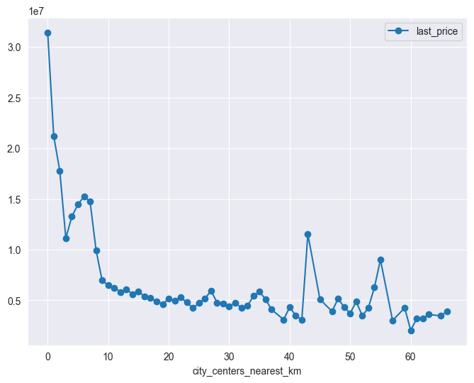

```python
#делаем выборку данных по г.Санкт-Петербург
center_spb = df.query('(locality_name == "Санкт-Петербург")')

#построим график зависимости стоимости квартиры от удаленности от центра г.Санкт-Петербург.
df.pivot_table(index='city_сenters_nearest_km', values='last_price').\
plot(style='o-', figsize=(8, 6), sharex=False, grid=True)

print('Коэффициент Пирсона для расчета корреляции удаленности от центра города Санкт-Петербург и цены квартиры:', \
      round(df['city_сenters_nearest_km'].corr(df['last_price']), 2))
```

присутствует очень слабая обратная связь. Чем дальше квартира от центра, тем дешевле.

```python
#посчитаем медиану цены квадратного метра квартиры по удаленности квартиры от центра г.Санкт-Петербург
center_spb_price_km = center_spb.pivot_table(index='city_сenters_nearest_km', values='price_sqm')
#считаем цену 1 километра для стоимости квадратного метра квартиры
center_spb_price_km['price_km'] = center_spb_price_km['price_sqm'] / center_spb_price_km.index
center_spb_price_km.loc[0, 'price_km'] = center_spb_price_km.loc[0, 'price_sqm']
display(center_spb_price_km)
```

| city_сenters_nearest_km | price_sqm | price_km |
| --- | --- | --- |
| 0.0 | 245833.111111 | 245833.111111 |
| 1.0 | 177004.963542 | 177004.963542 |
| 2.0 | 157848.564516 | 78924.282258 |
| 3.0 | 121507.367816 | 40502.455939 |
| 4.0 | 133351.114993 | 33337.778748 |
| 5.0 | 140453.507104 | 28090.701421 |
| 6.0 | 150946.333874 | 25157.722312 |
| 7.0 | 156176.445238 | 22310.920748 |
| 8.0 | 125649.319865 | 15706.164983 |
| 9.0 | 113158.927242 | 12573.214138 |
| 10.0 | 112607.030641 | 11260.703064 |
| 11.0 | 108381.317094 | 9852.847009 |
| 12.0 | 107475.809762 | 8956.317480 |
| 13.0 | 108098.659545 | 8315.281503 |
| 14.0 | 104200.775862 | 7442.912562 |
| 15.0 | 104230.097373 | 6948.673158 |
| 16.0 | 100542.168379 | 6283.885524 |
| 17.0 | 96969.791715 | 5704.105395 |
| 18.0 | 96361.839080 | 5353.435504 |
| 19.0 | 98657.955128 | 5192.523954 |
| 20.0 | 103044.775510 | 5152.238776 |
| 21.0 | 94469.136752 | 4498.530322 |
| 22.0 | 91329.965347 | 4151.362061 |
| 23.0 | 91828.070588 | 3992.524808 |
| 24.0 | 85736.461538 | 3572.352564 |
| 25.0 | 91531.038462 | 3661.241538 |
| 26.0 | 87798.441860 | 3376.863148 |
| 27.0 | 132115.000000 | 4893.148148 |
| 28.0 | 81161.571429 | 2898.627551 |
| 29.0 | 72952.666667 | 2515.609195 |

**Вывод о зависисмости стоимости квартир в Санкт-Петербурге от расстояния до центра города**

По графику можно примерно определить зону центра города Санкт-Петербург, как 7 км, т.к. дальше цена сильно отличается от того, что ближе. Значение центрального района 7 км также косвенно подтверждается распределением общего количества квартир (гистограмма выше), где первая крупная группа квартир находится именно на таком удалении.  
Произведен расчет цены 1 километра удаления от центра г. Санкт-Петербург для стоимости квадратного метра квартиры. Цена 1 км варьирутеся от 2500 до 245000.